## Analysis of top 20 packages downloads in 2015

#### Top 20 Packages downloads in 2105

```
##         package   count
## 1          Rcpp 2063718
## 2       ggplot2 1757949
## 3       stringr 1633875
## 4          plyr 1608749
## 5        digest 1474187
## 6      reshape2 1427212
## 7       stringi 1358745
## 8    colorspace 1345869
## 9        scales 1337716
## 10 RColorBrewer 1314448
## 11     magrittr 1280084
## 12     labeling 1131481
## 13      munsell 1130868
## 14       gtable 1117770
## 15    dichromat 1113945
## 16        proto 1106965
## 17          zoo 1070255
## 18         mime 1065914
## 19        RCurl  973218
## 20       bitops  958627
## 21           R6  943504
```

#### Pairs of Packages: Top 20 downloads in 2015 April

```
##                  packages downloadcount
## 1        digest & stringr         81193
## 2    colorspace & ggplot2         78828
## 3      reshape2 & ggplot2         73644
## 4        scales & ggplot2         72868
## 5        munsell & scales         72657
## 6       labeling & scales         72235
## 7      labeling & ggplot2         72183
## 8      munsell & labeling         72092
## 9     dichromat & munsell         72089
## 10        reshape2 & plyr         72071
## 11   dichromat & labeling         71910
## 12       gtable & ggplot2         71831
## 13       gtable & munsell         71816
## 14        gtable & scales         71783
## 15     dichromat & scales         71778
## 16      munsell & ggplot2         71542
## 17      gtable & labeling         71204
## 18     dichromat & gtable         71136
## 19            plyr & Rcpp         71122
## 20    dichromat & ggplot2         70792
## 21 RColorBrewer & ggplot2         70530
```

#### Packages Dependencies

Here, we explain why these pairs has the higher downloads than others.

Imports: packages listed here must be present for your package to work. In fact, any time your package is installed, those packages will, if not already present, be installed on your computer.(devtools::load_all( ) checks that the packages are installed).

Dependency: adding a package dependency here ensures that it’ll be installed. However, it does not mean that it will be attached along with your package

##### Example: ggplot2

ggplot2 package dependencies show below.

```r
pkgDep("ggplot2", suggests = FALSE, enhances = FALSE, availPkgs = cranJuly2014)
```

```
##  [1] "ggplot2"      "plyr"         "digest"       "gtable"
##  [5] "reshape2"     "scales"       "proto"        "MASS"
##  [9] "Rcpp"         "stringr"      "RColorBrewer" "dichromat"
## [13] "munsell"      "labeling"     "colorspace"
```

If we use install.packages(“ggplot2”) to download package, it automatically install its dependencies. Also, we need to install its import packages when we library(ggplot2).

Here is the relations for top 20 packages.

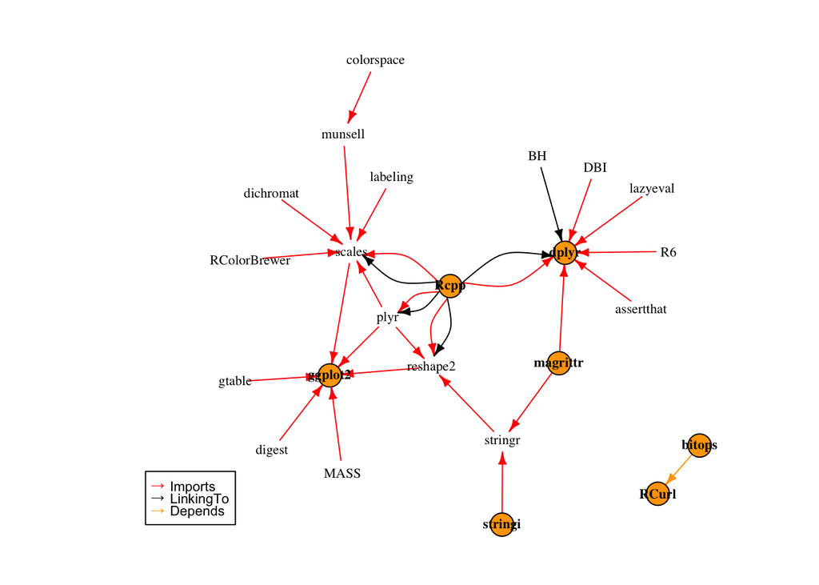

#### Rcpp by Reserved Linking To

This is another reason that Rcpp has the highest downloads.

Look at the LinkingTo Rcpp package:a declaration used to provide a C/C++ level dependency at the source code level. We use this in the Rcpp family to provide automatic resolution of the header files needed to compile against our packages. Unsurprisingly, because when packages using Rcpp actually use its API (rather than R functions), the package is a little ahead of others. In the package we find three more packages of the Rcpp family(Rcpp, RcppArmadillo, RcppEigen), but only a limited number of other packages as C/C++ level dependencies are still somewhat rare in the R universe. There are also fewer packages overall making use of this mechanism.

[interactive chart not shown]